# Machine learning for particle physics using R

Andrew John Lowe

Wigner Research Centre for Physics,  
Hungarian Academy of Sciences

# Introduction: about this talk

- I’m a particle physicist, programmer, and aspiring data scientist
  - Worked for 10 years on the development of core software and algorithms for a multi-stage cascade classifier that processes massive data in real-time (60 TB/s)
  - Previously a member of team that discovered the Higgs boson
  - I now work on using advanced machine learning techniques to develop classification algorithms for recognising subatomic particles based on their decay properties
- I’m going to talk about how switching to **R** has made it easier for me to ask more complex questions from my data than I would have been able to otherwise

# What is particle physics?

- The study of subatomic particles and the fundamental forces that act between them
- Present-day particle physics research represents man’s most ambitious and organised effort to answer the question: *What is the universe made of?*
- We have an extremely successful model that was developed throughout the mid to late 20th century
- But many questions still remain unanswered
  - Doesn’t explain: gravity, identity of dark matter, neutrino oscillations, matter/antimatter asymmetry of universe…
- To probe these mysteries, we built the **Large Hadron Collider**

# The Large Hadron Collider:

#### *a 10 billion dollar factory for producing massive amounts of physics data (30 PB/year)*

# LHC data flow

1. Detected by LHC experiment
2. Online multi-level filtering (hardware and software)
3. Transferred to Worldwide Computing Grid, processed in stages:
   - Tier-0: CERN (Geneva) and Wigner RCP (Budapest)
   - Tier-1: about a dozen large data centres located worldwide
   - Tier-2: institute and university clusters
4. Users run large analysis jobs on the Grid
5. Data written to locally-analysable files, put on PCs
6. Turned into plot in a paper

[figure not shown]

- For experimental particle physics, ROOT is the ubiquitous data analysis tool, and has been for the last 20 years
- Command language: CINT/CLANG (“interpreted C++”) or Python
  - Small data: work interactively or run macros
  - Big data: compile with ROOT libraries, run on Grid
- Data format optimised for large data sets
- Complex algorithms are difficult to do interactively
- End up writing huge C++ programs; endless edit-compile-run loops
- Frequent causes of frustration: difficult for beginners, unintuitive behaviour, hideous default plot style, baffling error messages
- A 100% non-transferable skill

[figure not shown]

- [TMVA](http://tmva.sourceforge.net/) is ROOT’s toolkit for machine learning
- TMVA contains: *feature selection*, *autoencoders*, *deep learning*… and many more things written from scratch that you’ll find elsewhere
- TMVA is single threaded and (unlike ROOT) doesn’t scale
- Cross validation natively supported in *next* release (not now)
  - External scripts to do this have existed only very recently
  - No nested cross validation

# Why did I choose R?

- Chief among those were the need for fast prototyping and high-level abstractions that let me concentrate on what I wanted to achieve, rather than on the mechanics and the highly-granular details of the implementation
  - Can do more with less typing
  - Incredibly easy to express what I want to achieve
- Exponentially-growing number of add-on packages
- Latest machine learning algorithms are available
- Great community; about 2 million R users worldwide
  - Technical questions are answered extremely quickly
- Beautiful plots that require very little tweaking for publication
- Pleasant user experience ☺

# My analysis:

### Identify particles based on their decay products

- Particles called **quarks** and **gluons** are produced copiously in proton-proton collisions at the LHC
- Quarks and gluons are not observed individually
- Instead, we can only measure their decay products
- What we observe is a cone-shaped spray of particles called a *jet*
- The measured particles are *clustered* by a jet algorithm (somewhat similar to *k-means*), and the resultant jets are viewed as a proxy to the initial quarks and gluons that we can’t measure
- Jets are a common feature in high-energy particle collisions

# The problem in a nutshell

- Beams of energetic protons collide inside our detector
- Quarks and gluons emerge and decay into sprays of particles
- Algorithms cluster these decay products into jets
- For each jet, we’d like to know what initiated it
- Was it a quark or a gluon?
- Being able to accurately discriminate between quark- and gluon-initiated jets would be an extremely powerful tool in the search for new particles and new physics
- This is an archetypal classification problem that might be amenable to machine learning

# Machine learning & particle physics

- Machine learning is more or less what is commonly known in particle physics as multivariate analysis (MVA)
- Used for many years but faced widespread scepticism
- Use of multivariate pattern recognition algorithms was basically taboo in new particle searches until recently
- Much prejudice against using what were considered “black box” selection algorithms
- Artificial neural networks and Fisher discriminants (linear discriminant analysis) were used somewhat in the 1990’s
- Boosted Decision Trees (AdaBoost, 1996) is the favourite algorithm used for many analyses (1st use: 2004)

# Data production pipeline

- Use experiment’s software to process Monte Carlo simulated data that contains lots of jets
  - Insert my own C++ code to compute handcrafted features
- Attach ground-truth class labels (“quark”/“gluon”) to each jet
- Write-out data and convert for use in R using **RootTreeToR**

# Cleaning data in R

- **data.table** is extremely useful here:
  - **fread** found to be at least twice as fast as other methods I tried
  - Helps me filter my data and is super-fast, especially using keys:

```r
setkey(DT, numTracks) # Set number of particle tracks to be the key
DT <- DT[!.(1)] # Remove all single-track jets
DT[, (bad.cols) := NULL] # Remove junk columns
```

- **dplyr** was invaluable for data analysis *dematryoshkafication*
  - Unwrap nested function calls
  - Data manipulation with dplyr mirrors the way we think about processing data: like on a production line, performing actions on an object sequentially, in a stepwise manner
  - Enables complex tasks to be constructed from simpler components that are glued together with the **%>%** operator

# More data munging

- To give me some extra space in RAM to work I used **SOAR** (stored object caches for R):

```r
Sys.setenv(R_LOCAL_CACHE = "soar_cache")
Store(DT) # data.table now stored as RData file on disk and out of RAM
```

- **caret** also provides some useful data-munging; I could reduce the size of my data by more than 50% with a conservative cut on correlations between features:

```r
highly.correlated <- findCorrelation(
  cor(DT[,-ncol(DT), with = FALSE], method = "pearson"),
  cutoff = 0.95, names = TRUE)
```

- Removing duplicate and highly-correlated features was critical for enabling my data to fit in RAM

# Data exploration

### Missingness map of the complete dataset

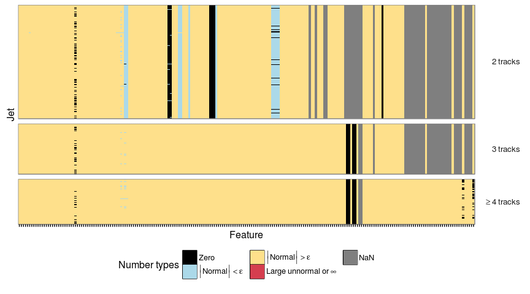

Missingness map that shows features with missing values, zero values, or values below the machine epsilon. I used this information to filter the data. Package: **ggplot2**.

### Magnitude map of the complete dataset

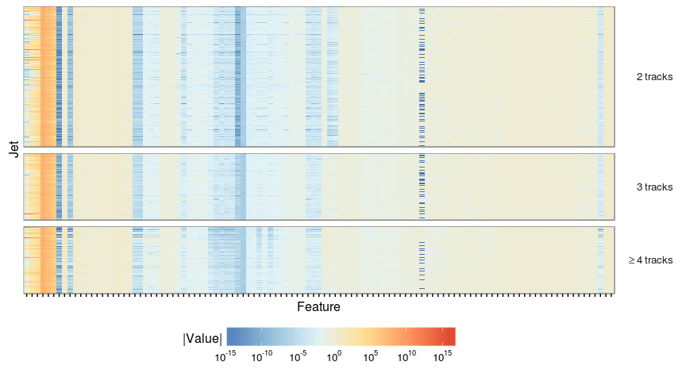

Magnitude map that shows variation in values of features before centering and scaling. Package: **ggplot2**.

### Visualising a correlation matrix as a force-directed network

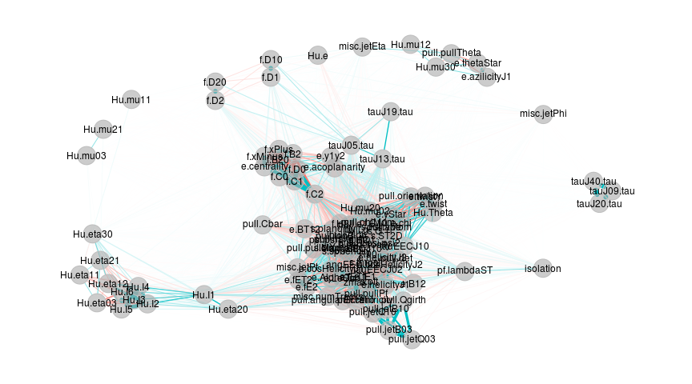

Connection strength between features (nodes) is proportional to their Pearson correlation. Package: **qgraph**.

# Dimensionality reduction

If we use linear or non-linear dimensionality reduction techniques to project the data into 2D, do we see any evidence for two distinct statistical populations of jets?

### Principal Component Analysis

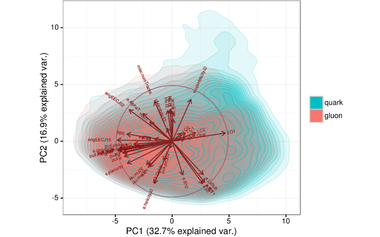

Covariance biplot: lengths of loading vectors approximate standard deviations, cosines between vectors approximate correlations. Overlaid is 2D KDE showing where the classes are distributed. Package: **ggbiplot**.

### t-Distributed Stochastic Neighbour Embedding

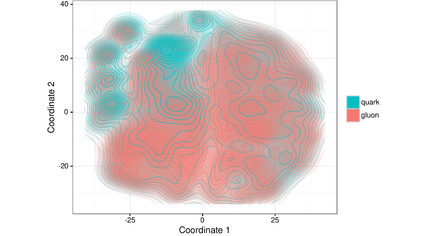

t-SNE is a popular method for exploring high-dimensional data. Package: **Rtsne**.

### Deep learning autoencoder with ICA whitening

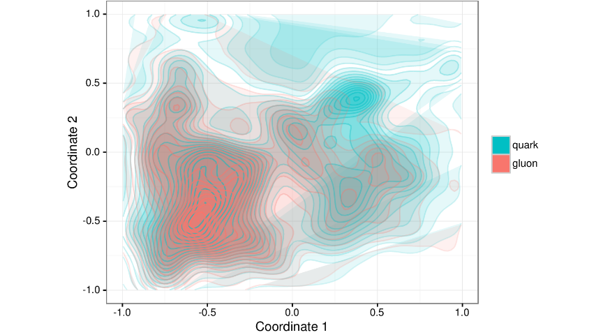

# Dimensionality reduction: conclusions

- No convincing evidence to support a hypothesis that quark- and gluon-initiated jets form two distinct populations
- The features are probably not informative enough
- There may be some easy cases from which we can produce a purified sample of quark-initiated jets, which would be useful for new particle searches

# Fast feature selection

- We want to find the variables that best explain the differences in physics between quark-jets and gluon-jets
- Ranked features using an entropy-based method from **CORElearn**
- Filter-based method that involves ranking by *information gain* (Kullback–Leibler divergence)
  - Information gain is based on the concept of entropy from information theory and is commonly used to decide which features to use when growing a decision tree
- To test method: inject random probes into the data, repeatedly calculate information gain for a large number of bootstrap resamplings and average

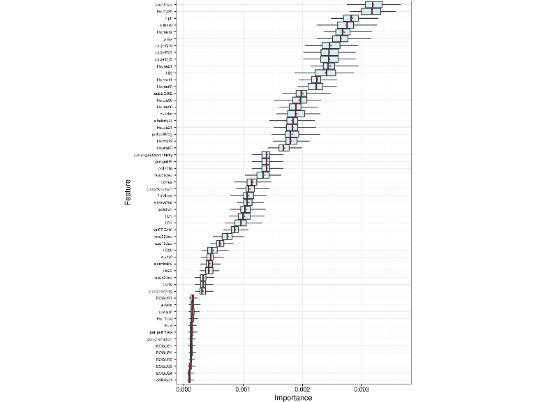

Distribution of information gain with 68% and 95% bootstrap-estimated confidence intervals for each feature.

### Removing redundant features using mutual information

- Information gain does not separate redundant features
- To filter redundant features, I used *mutual information*
  - In information theory, the mutual information (MI) of two random variables is a measure of their mutual dependence
  - Quantifies the “amount of information” obtained about one random variable, through the other random variable

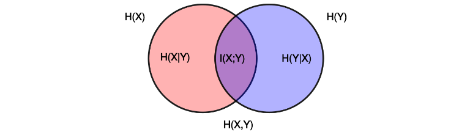

Venn diagram for various information measures associated with correlated variables X and Y. The area contained by both circles is the joint entropy H(X,Y). The circle on the left (red and violet) is the individual *Shannon entropy* H(X). The circle on the right (blue and violet) is H(Y). The violet is the **mutual information** I(X;Y).

### Mutual information: quantifies the degree of correlation between features

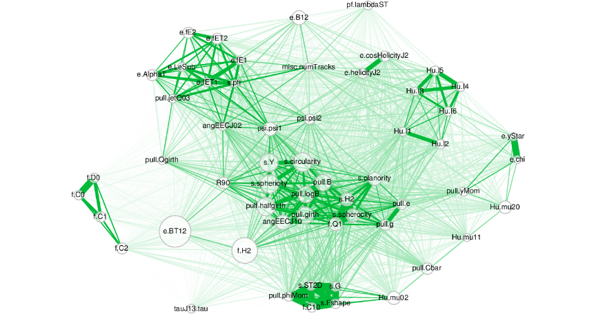

Mutual information matrix visualised as a force-directed network. Node size is proportional to information gain. Packages: **qgraph**, **WGCNA**.

### Feature redundancy: tests whether pairs of features have better joint discrimination than either feature individually

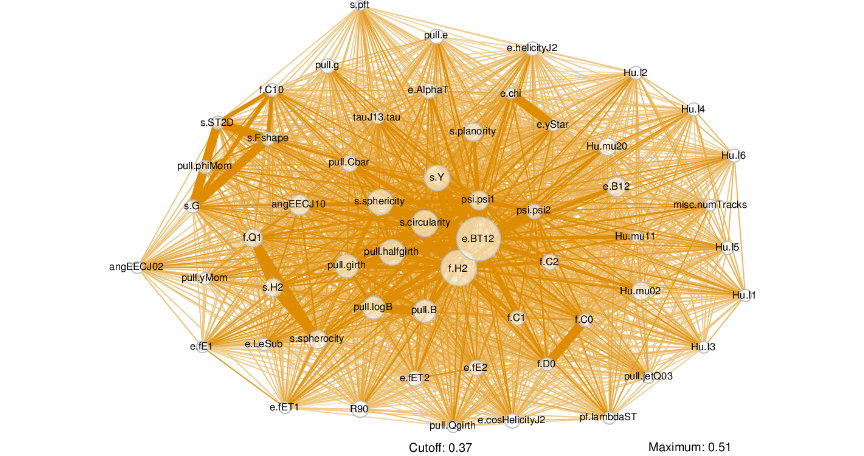

Feature redundancy matrix visualised as a force-directed network. Node size is proportional to information gain. Packages: **qgraph**, **WGCNA**.

# Results

- High degree of correlation between features, but some groups of features exist that are minimally correlated with each other
- Correlations between features that might hint at common sensitivity to underlying physics
- Probably a simple linear classifier might provide performance as good as we can get with this data
- New features have been found that were hitherto unknown, and these show promise in helping us understand the physics involved in the quark and gluon decay process

# Summary

- First-ever particle physics data analysis performed entirely in R
- Devised fast selection method that has found new discriminant variables that promise to improve discovery reach in searches for new particles at CERN and beyond
- Pioneered implementation of reproducible research by writing the first-ever fully reproducible and repurposable particle physics analysis paper using R Markdown
- R has enabled me to do far more than I could have achieved using only the standard tools available to particle physicists

# Thanks!

https://www.linkedin.com/in/andrewjohnlowe